# Starwars community detection

## 1.7 Assortativity coefficient.

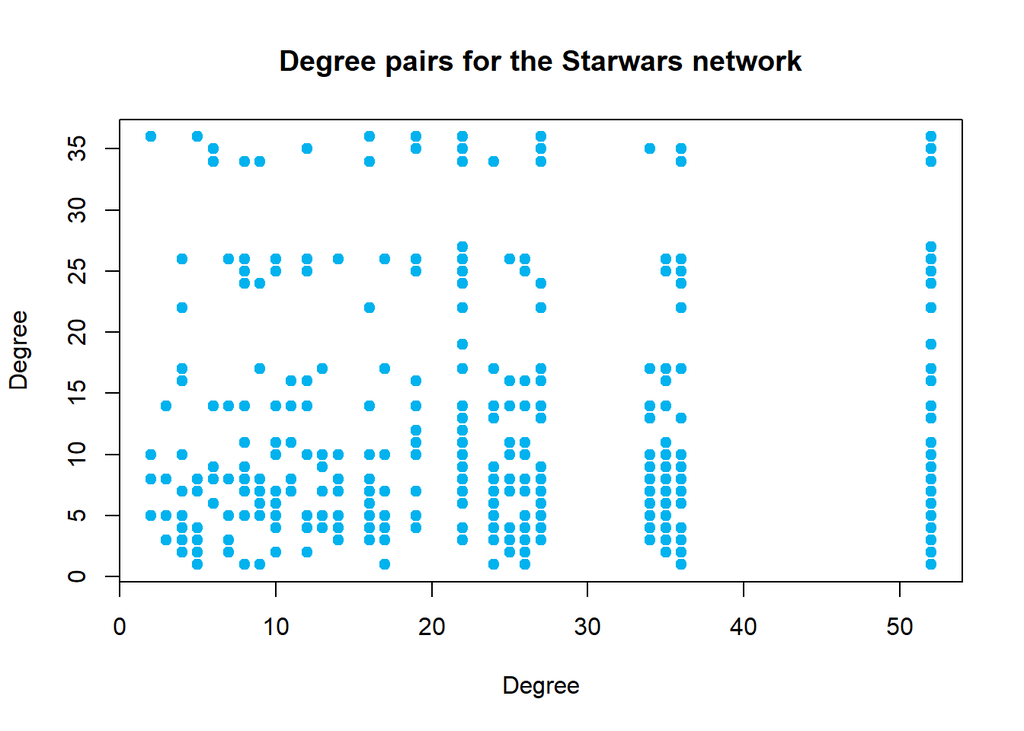

```r
degree.sw.network <- igraph::degree(sw.network)
sw.network.degrees <- matrix(NA,nrow=ecount(sw.network),ncol=2)
edges.sw.network <- get.edgelist(sw.network)
for (i in 1:ecount(sw.network)){sw.network.degrees[i,]<-degree.sw.network[edges.sw.network[i,]]}
plot(sw.network.degrees,pch=19,col="deepskyblue2",main="Degree pairs for the Starwars network",
     xlab="Degree",ylab="Degree")
```

```r
assortativity_degree(sw.network,V(sw.network))
```

```
## [1] -0.2086289
```

In an assortative network, we can see that the influencers tend to link to each other and avoid linking to small degree vertices, and, that these ones tend to connect to other small degree vertices. By taking a look at the plot of degree pairs we can see that Darth Vader which was the most connected character does not only connect to higher degree vertices, on the contrary, we can see that connects with a diversity of characters, this behavior is replicable for other important characters. Also, we can see that characters with smaller degree also connect to higher degree vertices. Furthermore, if we take a look at the assortative ratio, we can see that with a negative value of -0.2086, this measurement indicates the disassortativeness of it. This is expected because of the nature of the dataset, recall that this network presents the characters in the episodes of Starwars and the connections with each other based on the scenes that made together, consequently, we could expect that characters that appear the most and are considered the most important ones will be acting with less participative characters as well.